# Week7 Assignment

Michelle Gregoire

2022-03-09

## Objective and setting up for assignment

For this week’s assignment we first have to make a directory called “Week7”

- mkdir Week7
- cd Week7

Then we have to create our environment

- conda create -n week7 ddocent
- conda activate week7

## Link to the data

- ln -s /home/BIO594/Exercises/Week07_and_Week_08/simulated/*.fq.gz .

## Then run dDocent

dDocent

- Number of processors: 20
- Maximum memory: 0
- Trimming: yes
- Assembly: yes
- Type of assembly: PE
- Clustering similarity: 0.9
- Mapping reads: yes
- Mapping match value: 1
- Mapping mis-match value: 4
- Mapping gapOpen penalty: 6
- Calling SNPs: yes
- email: mjgregoire@uri.edu
- Cutoff values: 5, 3

To run dDocent in the background of your terminal:

- Press ‘ctrl’ + z
- Type bg and hit ‘–> enter’
- Type disown -h

## Filter SNPs

We now need to filter the data to see if we can tease out any significant SNPs. Make a new directory called “Filter” and move into that directory

- mkdir Filter
- cd Filter

Link to the total raw SNPs VCF file from the Week7 directory

- ln -s ../TotalRawSNPs.vcf .

Run VCF tools on this file with the following parameters and recode keeping the info fields and name the output file TRS:

- Proportion of missing data to exclude “Max missing”: 0.5
- Minor allele frequency “maf”: 0.001
- Minimum Q value to include sites above “MinQ”: 20
- vcftools –vcf TotalRawSNPs.vcf –max-missing 0.5 –maf 0.001 –minQ 20 –recode –recode-INFO-all –out TRS

-vcftools –vcf TRS.recode.vcf –minDP 5 –recode –recode-INFO-all –out TRSdp5

Get rid of any missing data from the population map with a value 0.05:

- pop_missing_filter.sh TRSdp5.recode.vcf ../popmap 0.05 1 TRSdp5p05

Run the dDocent filter:

- dDocent_filters TRSdp5p05.recode.vcf TRSdp5p05

It will ask if the reads are expected to overlap: No And if the library is from a mix of SE and PE: No

It will generate a histogram and ask you to choose a cutoff value as follows:

-If distrubtion looks normal, a 1.645 sigma cutoff (~90% of the data) would be 5156.132535. The 95% cutoff would be 63. Would you like to use a different maximum mean depth cutoff than 63, yes or no

Say yes and enter a higher cutoff ex: 70

- vcfallelicprimitives -k -g TRSdp5p05.FIL.recode.vcf |sed ‘s:.|.:./.:g’ > TRSdp5p05F.prim

Then we will run the prim file in vcf tools and remove any indels, save the output as SNP.TRSdp5p05F:

- vcftools –vcf TRSdp5p05F.prim –recode –recode-INFO-all –remove-indels –out SNP.TRSdp5p05F

Next we can filter the data further by HardyWeinberg and save the output as SNP.TRSdp5p05FHWE:

- filter_hwe_by_pop.pl -v SNP.TRSdp5p05F.recode.vcf -p ../popmap -c 0.5 -out SNP.TRSdp5p05FHWE

Then run vcftools to filter this HardyWeinberg filtered set to include sites with a minimum allelic frequency of 0.05, recode this and save the output as SNP.TRSdp5p05FHWEmaf05:

- vcftools –vcf SNP.TRSdp5p05FHWE.recode.vcf –maf 0.05 –recode –recode-INFO-all –out SNP.TRSdp5p05FHWEmaf05

## Converting VCF to other file formats

VCF files can be converted into other file formats depending on the intended analysis. We will accomplish the coversion by copying a PGDspider configuration file and link to the popmap in the Week7 directory to map the individuals back to the population.

- cp /home/BIO594/DATA/Week7/example/BSsnp.spid .
- ln -s ../popmap .

Use the following command to run PGDspider which is a java program. Specify your input file as the SNP.TRSdp5p05FHWEmaf05.recode.vcf file and your output as SNP.TRSdp5p05FHWEBS:

- java -jar /usr/local/bin/PGDSpider2-cli.jar -inputfile SNP.TRSdp5p05FHWEmaf05.recode.vcf -outputfile SNP.TRSdp5p05FHWEBS -spid BSsnp.spid

## Running BayeScan

BayeScan is used to identify loci that are under natural selection. It looks at differences in allele frequencies between populations and uses a multinomial-Dirichlet model. The differences in allele frequencies are measured by subpopulation specific FsT coefficients.

Use the following command to run BayeScan, note this will take a while to run:

- BayeScan2.1_linux64bits SNP.TRSdp5p05FHWEBS -nbp 30 -thin 20

Copy the R source file into the Filter folder so that you can analyze the output from BayeScan:

- cp /home/BIO594/DATA/Week7/example/plot_R.r .

Then open R-Studio and use the following commands to visually see the output from BayeScan. The outliers with the more negative log10 quality (Q) values indicate the SNPs of interest:

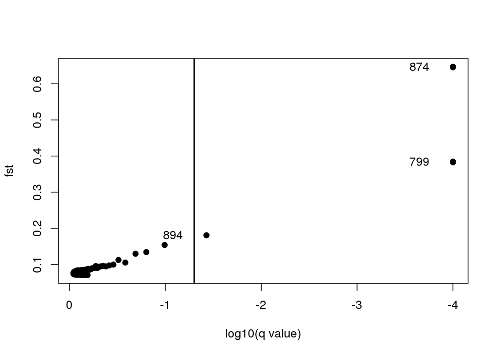

```
## $outliers
## [1] 798 799 873 874 894
##
## $nb_outliers
## [1] 5
```

```r
source("/home/mgregoire/Week7/Filter/plot_R.r")
plot_bayescan("/home/mgregoire/Week7/Filter/SNP.TRSdp5p05FH_fst.txt")
```

BayeScan can use multiallelic data but PCAdapt and Outflank can only process SNPs with only two alleles. Use the following command to do this:

- vcftools –vcf SNP.TRSdp5p05FHWEmaf05.recode.vcf –max-alleles 2 –recode –recode-INFO-all –out SNP.TRSdp5p05FHWE2A

## Analyzing data with PCAdapt

PCAdapt is an R based program that detects genetic markers involved in biological adaptation using tools for outlier detection based on Principal Component Analysis (PCA). All analysis once you filter for the two alleles (from the previous step) can be done in R.

```r
#load pcadapt library
library(pcadapt)

#load VCF file into R
filename <- read.pcadapt("/home/mgregoire/Week7/Filter/SNP.TRSdp5p05FHWE2A.recode.vcf", type = "vcf" )
```

```
## 125 variant(s) have been discarded as they are not SNPs.
## Summary:
##
##  - input file:               /home/mgregoire/Week7/Filter/SNP.TRSdp5p05FHWE2A.recode.vcf
##  - output file:              /tmp/RtmplCVrmb/file117337f486895.pcadapt
##
##  - number of individuals detected:   80
##  - number of loci detected:      922
##
## 797 lines detected.
## 80 columns detected.
```

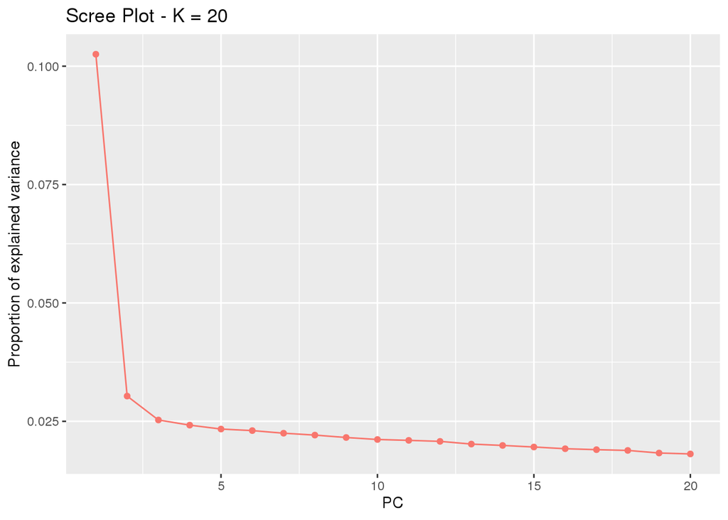

```r
#create first PCA
x <- pcadapt(input = filename, K = 20)

#plot the likelihoods
plot(x, option = "screeplot")
```

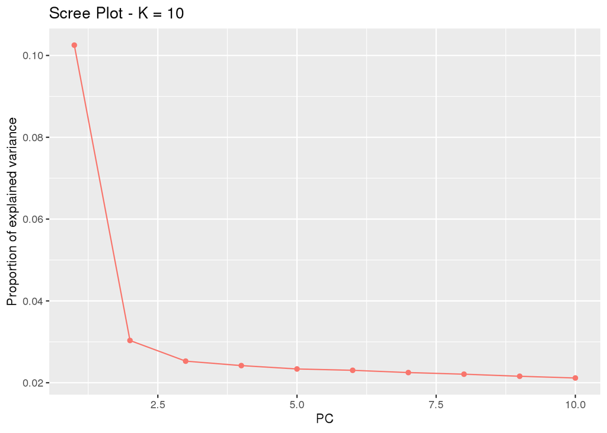

```r
#plot Plot the likelihoods for only first 10 K
plot(x, option = "screeplot", K = 10)
```

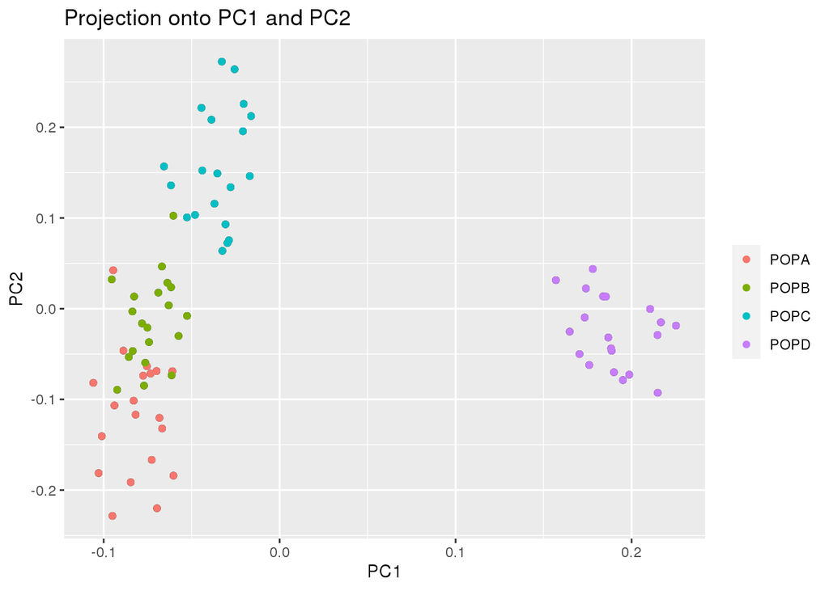

```r
#create population designations
poplist.names <- c(rep("POPA", 20),rep("POPB", 20),rep("POPC", 20), rep("POPD",20))

#plot the actual PCA (first two PCAs)
plot(x, option = "scores", pop = poplist.names)
```

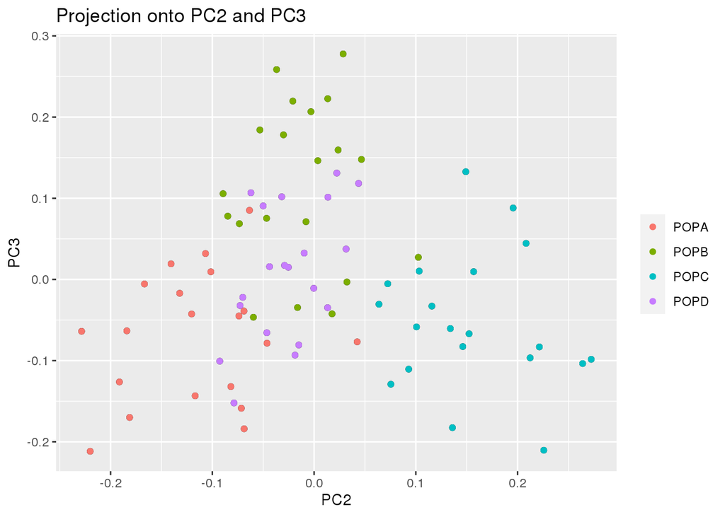

```r
#plot PCA with PCA 2 and PCA 3
plot(x, option = "scores", i = 2, j = 3, pop = poplist.names)
```

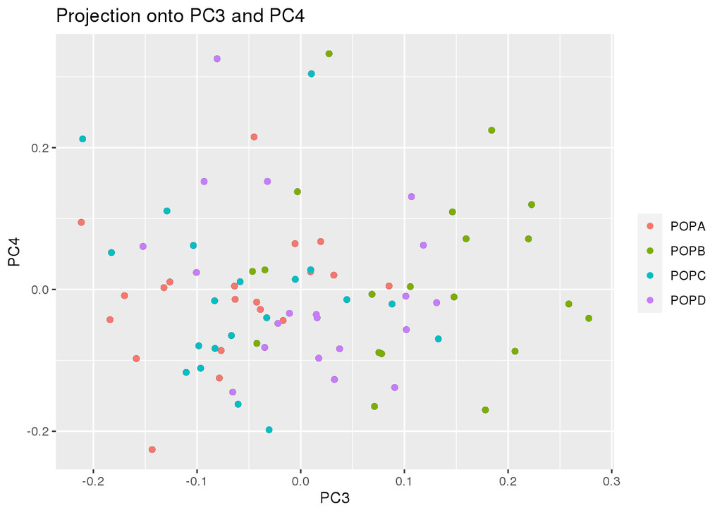

```r
#plot PCA with PCA 3 and PCA 4
plot(x, option = "scores", i = 3, j = 4, pop = poplist.names)
```

```r
#redo PCA with only 3 K
x <- pcadapt(filename, K = 3)

summary(x)
```

```
##                 Length Class  Mode
## scores           240   -none- numeric
## singular.values    3   -none- numeric
## loadings        2391   -none- numeric
## zscores         2391   -none- numeric
## af               797   -none- numeric
## maf              797   -none- numeric
## chi2.stat        797   -none- numeric
## stat             797   -none- numeric
## gif                1   -none- numeric
## pvalues          797   -none- numeric
## pass             797   -none- numeric
```

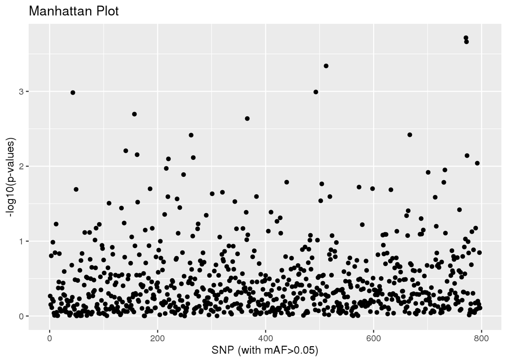

```r
#start looking for outliers
#make Manhattan Plot
plot(x , option = "manhattan")
```

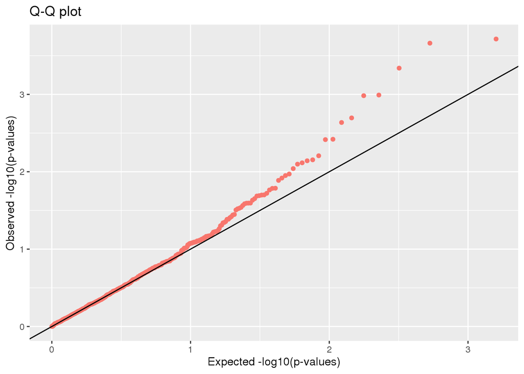

```r
#make qqplot
plot(x, option = "qqplot", threshold = 0.1)
```

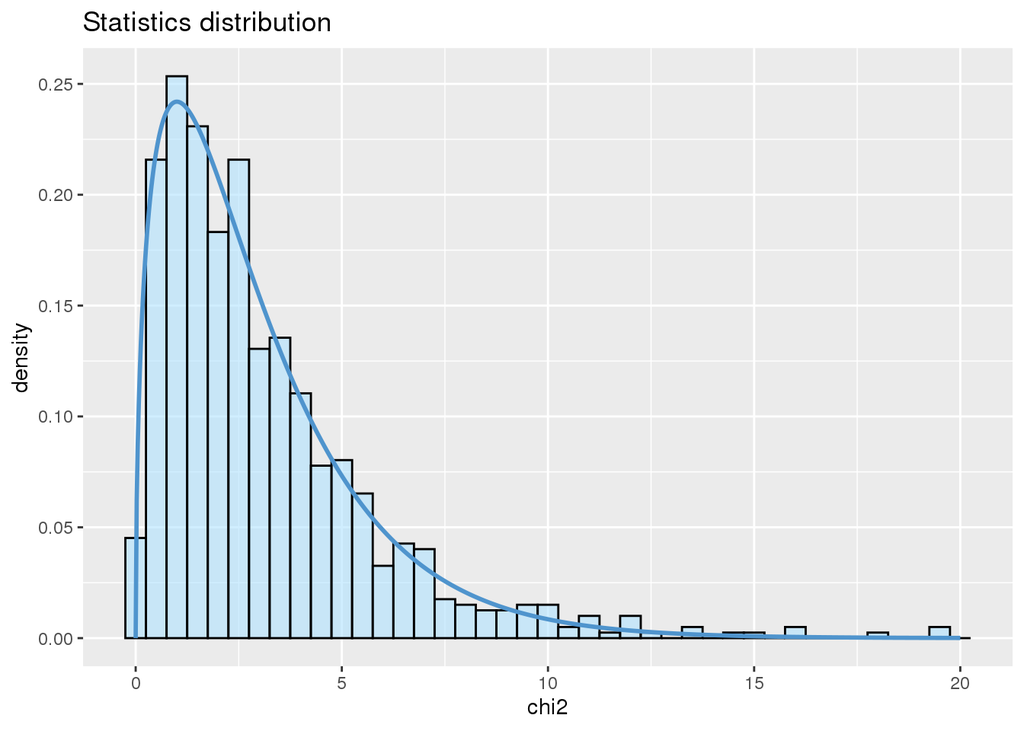

```r
#look at P-value distribution
plot(x, option = "stat.distribution")
```

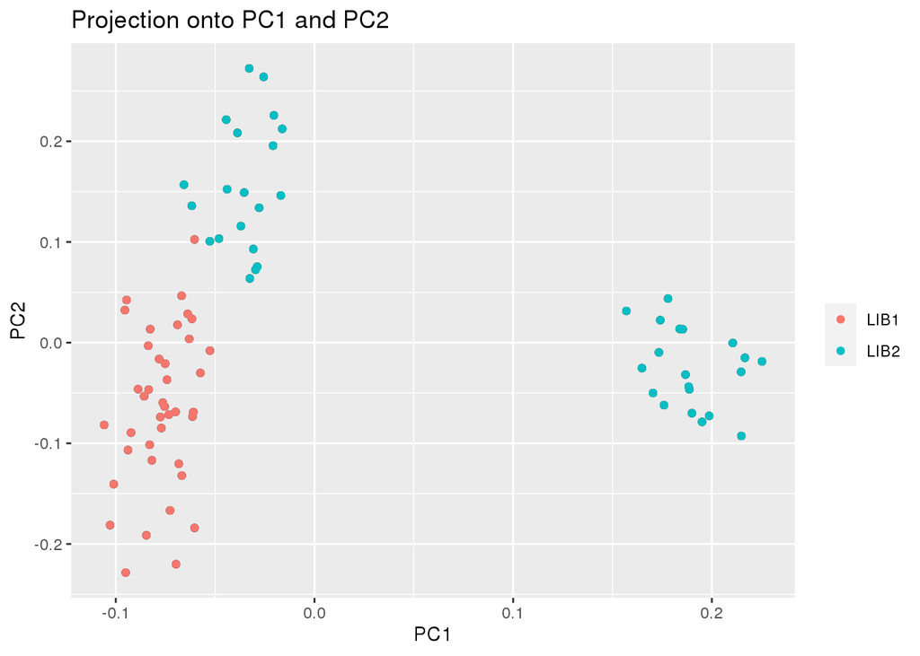

```r
#set FDR
library(qvalue)
qval <- qvalue(x$pvalues)$qvalues
alpha <- 0.1

#save outliers
outliers <- which(qval < alpha)

#test for library effects
poplist.names <- c(rep("LIB1", 40),rep("LIB2", 40))
x <- pcadapt(input = filename, K = 20)

plot(x, option = "scores", pop = poplist.names)
```

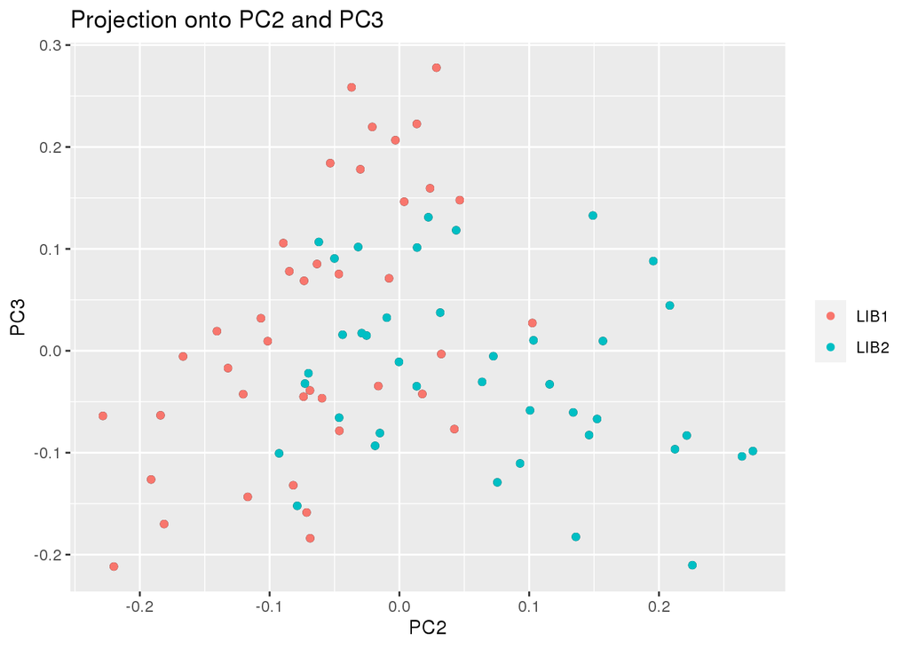

```r
plot(x, option = "scores", i = 2, j = 3, pop = poplist.names)
```

```r
x <- pcadapt(filename, K = 2)
summary(x)
```

```
##                 Length Class  Mode
## scores           160   -none- numeric
## singular.values    2   -none- numeric
## loadings        1594   -none- numeric
## zscores         1594   -none- numeric
## af               797   -none- numeric
## maf              797   -none- numeric
## chi2.stat        797   -none- numeric
## stat             797   -none- numeric
## gif                1   -none- numeric
## pvalues          797   -none- numeric
## pass             797   -none- numeric
```

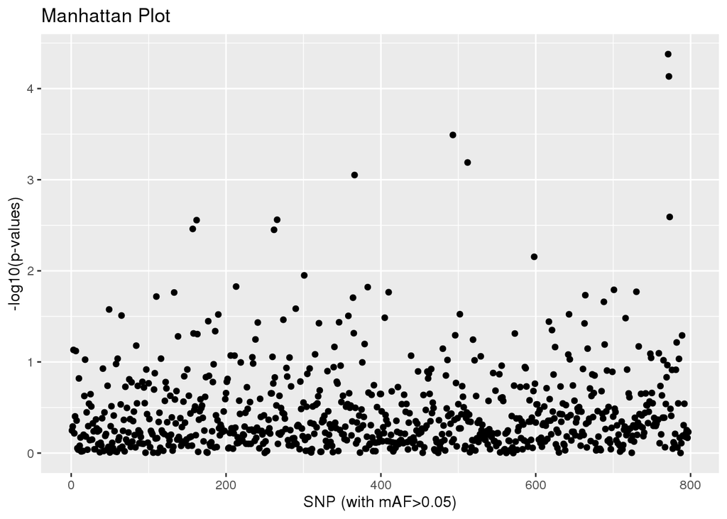

```r
#make your plots
plot(x , option = "manhattan")
```

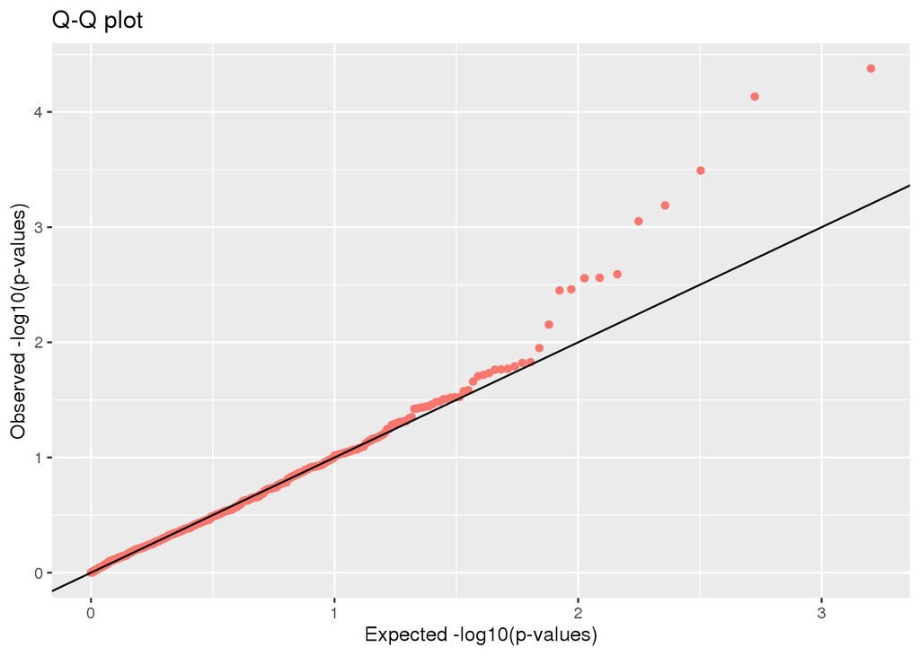

```r
plot(x, option = "qqplot", threshold = 0.1)
```

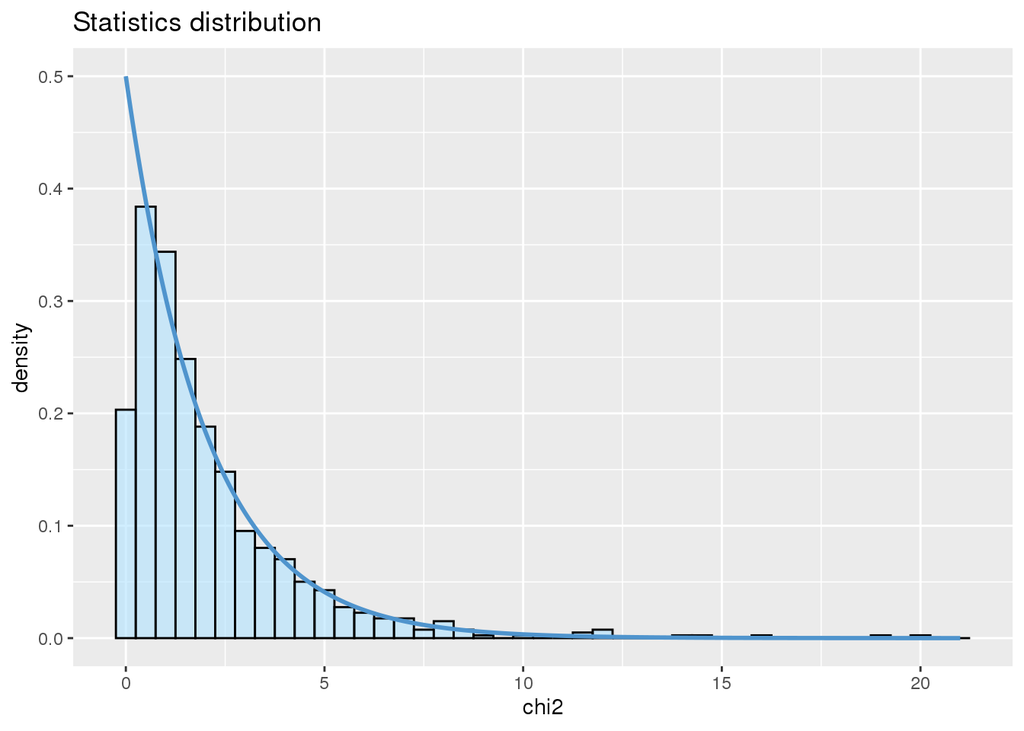

```r
plot(x, option = "stat.distribution")
```

```r
library(qvalue)
qval <- qvalue(x$pvalues)$qvalues
alpha <- 0.1
outliers <- which(qval < alpha)
```

## Analyzing data with Outflank

Outflank can find Fst outliers in data based on an inferred distribution of neutral Fst. It can be run entirely in R once you have only allelic data from two alleles.

```r
#load the OutFLANK, vcfR, and LD pruning (bigsnpr), packages
library(OutFLANK)
library(vcfR)
library(bigsnpr)
#read in your vcf file
my_vcf <- read.vcfR("/home/mgregoire/Week7/Filter/SNP.TRSdp5p05FHWE2A.recode.vcf")
```

[output not shown]

```r
#make a character matrix with the genotypes
geno <- extract.gt(my_vcf)
#add the positions in bp
position <- getPOS(my_vcf)
#add the chromosome information
chromosome <- getCHROM(my_vcf)

#modify the table to show the genotypes simply
G <- matrix(NA, nrow = nrow(geno), ncol = ncol(geno))
G[geno %in% c("0/0", "0|0")] <- 0
G[geno  %in% c("0/1", "1/0", "1|0", "0|1")] <- 1
G[geno %in% c("1/1", "1|1")] <- 2
G[is.na(G)] <- 9
head(G[,1:10])
```

```
##      [,1] [,2] [,3] [,4] [,5] [,6] [,7] [,8] [,9] [,10]
## [1,]    2    2    1    2    2    2    2    2    2     2
## [2,]    2    1    2    1    1    2    2    1    2     2
## [3,]    2    2    1    1    1    2    2    2    2     2
## [4,]    0    0    0    0    0    1    1    0    0     0
## [5,]    0    0    0    0    0    0    0    0    0     0
## [6,]    0    0    0    0    0    0    0    0    0     0
```

```r
#load the popmap from the Week7 folder and info under variable "pop"
pop <- read.table("/home/mgregoire/Week7/popmap", header=FALSE)
pop <- pop$V2

#use the chromosome, position, and popmaps with the MakeDiploidFSTMat command to get the FST
my_fst <- MakeDiploidFSTMat(t(G), locusNames = paste0(chromosome,"_", position), popNames = pop)
```

```
## Calculating FSTs, may take a few minutes...
```

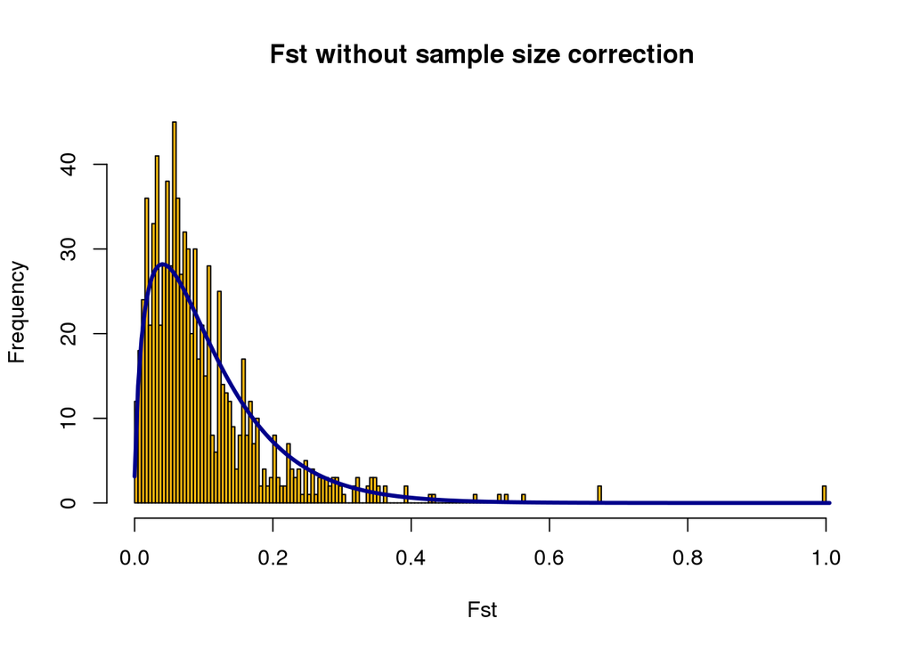

```r
#use the OutFLANK command to finish up the analysis
my_dist <- OutFLANK(my_fst, NumberOfSamples = 4, qthreshold=0.1, RightTrimFraction=0.1, LeftTrimFraction=0.1)

#use outFLANKResultsPlotter to visualize and retrieve your results
OutFLANKResultsPlotter(my_dist)
```

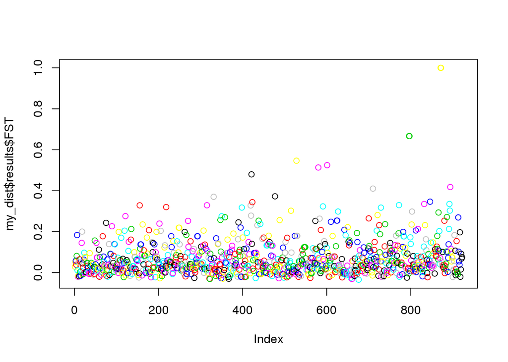

```r
plot(my_dist$results$FST, col=as.numeric(as.factor(chromosome)))
```

```r
my_dist$results[which(my_dist$results$OutlierFlag == TRUE),]
```

```
##                 LocusName        He       FST        T1        T2 FSTNoCorr
## 796 dDocent_Contig_944_78 0.2805469 0.6666667 0.1125000 0.1687500     0.675
## 797 dDocent_Contig_944_80 0.2805469 0.6666667 0.1125000 0.1687500     0.675
## 871 dDocent_Contig_984_86 0.5000000 1.0000000 0.3333333 0.3333333     1.000
## 872 dDocent_Contig_984_89 0.5000000 1.0000000 0.3333333 0.3333333     1.000
##      T1NoCorr  T2NoCorr meanAlleleFreq indexOrder GoodH      qvalues
## 796 0.1139063 0.1687500        0.83125        796 goodH 0.0340653515
## 797 0.1139063 0.1687500        0.83125        797 goodH 0.0340653515
## 871 0.3333333 0.3333333        0.50000        871 goodH 0.0006013486
## 872 0.3333333 0.3333333        0.50000        872 goodH 0.0006013486
##          pvalues pvaluesRightTail OutlierFlag
## 796 3.172559e-04     1.586279e-04        TRUE
## 797 3.172559e-04     1.586279e-04        TRUE
## 871 2.800226e-06     1.400113e-06        TRUE
## 872 2.800226e-06     1.400113e-06        TRUE
```

## Analyzing Data with BayEnv2

BayEnv2 is a data analysis tool that can detect loci involved in local adaptation that show a correlation between allele frequencies and ecological variables or differences between geographic regions. This analysis is not done in R until the last few steps, so go back to your terminal!

First the vcf file needs to be converted into a file that BayEnv2 recognizes use the following code:

- cp /home/BIO594/DATA/Week7/example/SNPBayEnv.spid .
- cp /home/BIO594/DATA/Week7/example/environ .
- java -jar /usr/local/bin/PGDSpider2-cli.jar -inputfile SNP.TRSdp5p05FHWE2A.recode.vcf -outputfile SNP.TRSdp5p05FHWEBayEnv.txt -spid SNPBayEnv.spid

Then call BayEnv2 to generate a covariance matrix:

- bayenv2 -i SNP.TRSdp5p05FHWEBayEnv.txt -p 4 -k 100000 -r 63479 > matrix.out

The code will generate 100,000 iterations. We only need the last one so filter that out

- tail -5 matrix.out | head -4 > matrix

Look at the environmental factor file:

- cat environ

Next calculate the Bayes Factor for each SNP for each environmental variable, note this will take awhile:

- ln -s /usr/local/bin/bayenv2 .
- calc_bf.sh SNP.TRSdp5p05FHWEBayEnv.txt environ matrix 4 10000 2

Next convert the output into a file that is suitable to be opened in R:

- paste <(seq 1 923) <(cut -f2,3 bf_environ.environ ) > bayenv.out
- cat <(echo -e “Locus”) bayenv.out > bayenv.final

Then you can open R and run the following:

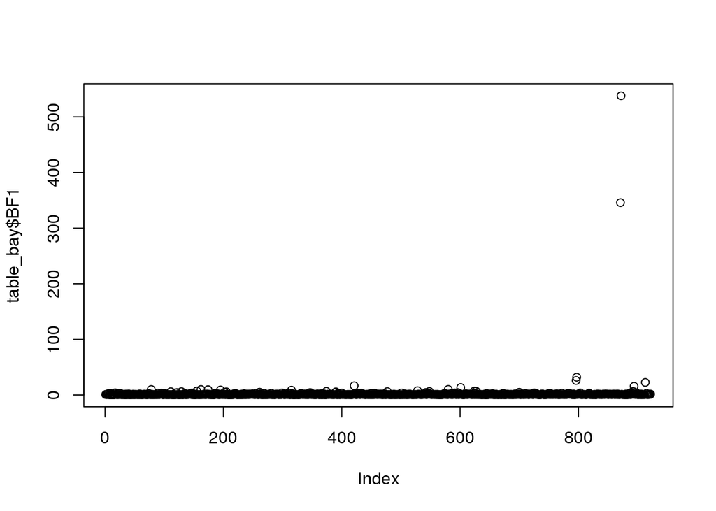

```r
#use fill to fill = TRUE to fill any gaps in the table
table_bay <- read.table("/home/mgregoire/Week7/Filter/bayenv.final",header=TRUE, fill = TRUE)
#visualize the table by plotting it
plot(table_bay$BF1)
```

```r
#print the significant values in the table
table_bay[which(table_bay$BF1 > 100),]
```

```
##     Locus    BF1     BF2
## 871   871 345.96 0.80532
## 872   872 537.99 1.22770
```

## Summary

In this assignment we have practiced calling SNPs from our simulated population data with dDocent, filtering the SNPS with vcftools, converting vcf files to other formats, and analyzing the SNPs for outliers using BayeScan, PCAdapt, OutFLANK, and BayEnv2 –each of which calls upon different statistical analyses and models to determine SNP outlier significance.